# Homework 5

Gurusharan Kunusoth

## Section I: Normal distribution

### 1

#### 1A

What is the 0.975 quantile of the standard normal distribution?

```r
# insert code here
qnorm(0.975)
```

```
## [1] 1.959964
```

#### 1B

What is the area to the right of this quantile?

> The area to the right of this quantile represents the probability that an observation is greater than the 0.975 quantile.

### 2

For the $\text{N}(500,100)$ distribution, find values $a$ and $b$ such that $a < b$, the area between $a$ and $b$ under the normal density is equal to 0.6, and $a$ and $b$ are equally distant from $\mu = 500$.

```r
# insert code here
mean_val <- 500
standard_dev <- 100

z_a <- qnorm(0.5 - 0.6 / 2)

a <- mean_val + z_a * standard_dev

z_b <- qnorm(0.5 + 0.6 / 2)

b <- mean_val + z_b * standard_dev

a
```

```
## [1] 415.8379
```

```r
b
```

```
## [1] 584.1621
```

### 3

Graph the $\text{N}(500,100)$ distribution and shade the area between $a$ and $b$ from the previous problem.

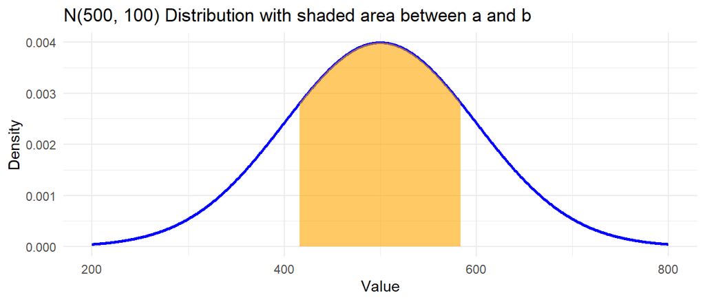

```r
# insert code here
tempDF = data.frame(x = seq(200, 800, length.out = 1000), density = dnorm(seq(200, 800, length.out = 1000), mean = mean_val, sd = standard_dev))

plot = ggplot(tempDF, aes(x = x, y = density)) + geom_line(color = "blue", size = 1) +
  geom_area(data = filter(tempDF, x >= a & x <= b),
             aes(y = density),
             fill = "orange",
             alpha = 0.6) +
  theme_minimal() +
  labs(x = "Value",
       y = "Density",
       title = "N(500, 100) Distribution with shaded area between a and b")
print(plot)
```

## Section II: Binomial inference

- The data are in the file `chimpanzee.csv` (same as lecture or discussion).
- These data are artificial, but created to match details from a 2011 PNAS paper on chimpanzee prosocial choice.
- See the [Course Notes and Case Studies Chapter 18](https://bookdown.org/bret_larget/stat-240-case-studies/chimpanzees-and-prosocial-choice.html) for background on the data.

### 4

The goal of this question is to create a graphic to visualize confidence intervals for the proportion of times the prosocial token is selected by the chimpanzees. Read in the `chimpanzee.csv` data file, then follow the steps below.

- Make a plot that displays a **point** at the proportion of times the prosocial choice is made (i.e., the point estimate $\hat{p}$) in trials when a partner is present and in trials when a partner is not present. These estimates are based on all the chimpanzee actors data combined. This will result in two points on your graphic for this step. The y-axis is for the estimated proportion and the x-axis is for the experimental condition (“with a partner” or “without a partner”).
- Add a thin blue (vertical) line segment for each point to visualize a 95% Wald confidence interval. The lines should extend vertically from the lower bound to the upper bound of the confidence interval, and the point estimate from the previous step will be in the middle of the interval.
- Similarly, add a slightly thicker black segment to visualize the interval one standard error above and below the point estimates.
- Add a horizontal red dashed line at p = 0.5.
- Label axes appropriately and add an informative title to the plot.

Note: Make sure your point estimates are clearly visible on the graphic. We recommend you add the 95% confidence interval first, then add the the SE interval, and finally the point estimate.

*Hint: Your final plot should have two vertical lines with the layered segments for the CIs and the SE intervals, a point in the center of each vertical line, and a horizontal dashed line.*

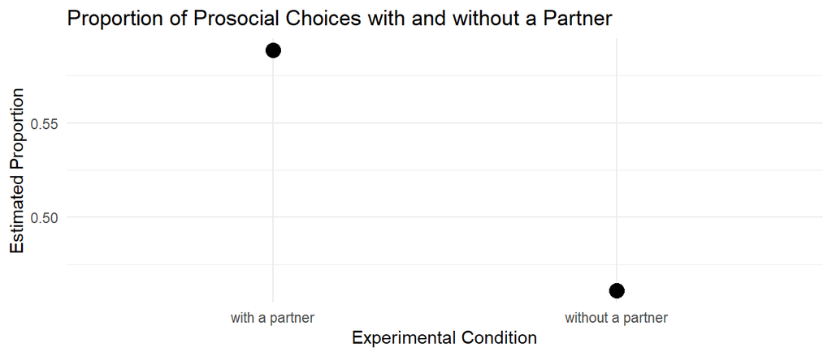

```r
# insert code here
chimpanzee = read_csv("chimpanzee.csv")

withPartner = chimpanzee %>%
  filter(partner != 'none')
withoutPartner = chimpanzee %>%
  filter(partner == 'none')

propWithPartner = sum(withPartner$prosocial) / sum(withPartner$prosocial, withPartner$selfish)
propWithoutPartner = sum(withoutPartner$prosocial) / sum(withoutPartner$prosocial, withoutPartner$selfish)

newData = data.frame(
  partnerPresent = c("with a partner", "without a partner"),
  proportionProsocial = c(propWithPartner, propWithoutPartner)
)

print(ggplot(newData, aes(x = partnerPresent, y = proportionProsocial)) +
  geom_point(size = 4) +
  labs(title = "Proportion of Prosocial Choices with and without a Partner",
       x = "Experimental Condition",
       y = "Estimated Proportion") +
  theme_minimal())
```

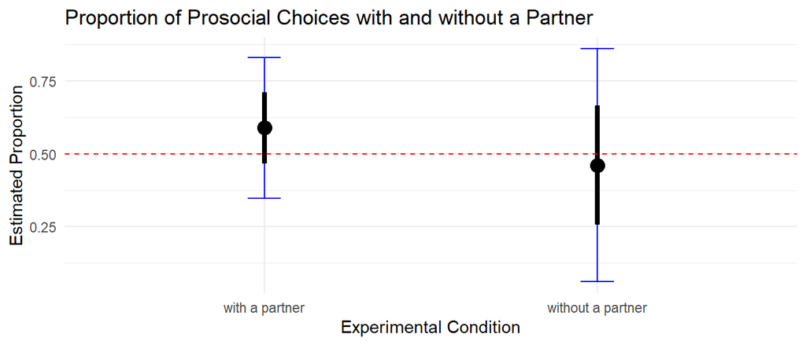

```r
seWithPartner = sqrt(propWithPartner * (1 - propWithoutPartner) / nrow(withPartner))
seWithoutPartner = sqrt(propWithoutPartner * (1 - propWithoutPartner) / nrow(withoutPartner))

alpha = 0.05
z = qnorm(1 - alpha / 2)
ciWithPartner = c(propWithPartner - z * seWithPartner, propWithPartner + z * seWithPartner)
ciWithoutPartner = c(propWithoutPartner - z * seWithoutPartner, propWithoutPartner + z * seWithoutPartner)

seIntervalWithPartner = c(propWithPartner - seWithPartner, propWithPartner + seWithPartner)
seIntervalWithoutPartner = c(propWithoutPartner - seWithoutPartner, propWithoutPartner + seWithoutPartner)

newPlot = data.frame(
  partnerPresent = c("with a partner", "without a partner"),
  propProsocial = c(propWithPartner, propWithoutPartner),
  lowerBound = c(ciWithPartner[1], ciWithoutPartner[1]),
  upperBound = c(ciWithPartner[2], ciWithoutPartner[2]),
  seLowerBound = c(seIntervalWithPartner[1], seIntervalWithoutPartner[1]),
  seUpperBound = c(seIntervalWithPartner[2], seIntervalWithoutPartner[2])
)

ggplot(newPlot, aes(x = partnerPresent, y = propProsocial)) +
  geom_point(size = 4) +
  geom_errorbar(aes(ymin = lowerBound, ymax = upperBound), width = 0.1, color = "blue") +
  geom_linerange(aes(ymin = seLowerBound, ymax = seUpperBound), size = 1.5, color = "black") +
  geom_hline(yintercept = 0.5, linetype = "dashed", color = "red") +
  labs(
    title = "Proportion of Prosocial Choices with and without a Partner",
    x = "Experimental Condition",
    y = "Estimated Proportion"
  ) +
  theme_minimal()
```